# Boxplots of mC in 100 kbp bins

Tomato TET3 BS-seq screening test

Javier Antúnez Sánchez

September 2022

Analysis of DNA methylation in 100 kbp bins created with `CX_report2mC_bins.v1.0.pl` from Bismark CX_reports.

# Load and filter data

When loading data I filter samples Undetermined (reads that couldn’t be assigned to any library), neg, PBS (controls), A1_2 & B2_13 (samples with almost no reads). I also filter extranuclear genomes (Mitochondrion and Chloroplast) and chromosome 9 as there is an anomaly in the mapping.

I filter out the samples that contain less than 14 Million Cytosines covered (WT_6, A_1, A_12, B_6, B_11, B_5, B1_2, B2_14, B2_18 & B2_20) as outliers as explained in the bins PCA report.

For each bean I computed the average across the 4 WT plants and obtain the difference to that from each sample.

## Coverage check

Some quality check for the coverage levels of this 100 kbp bins

### raincloud plot

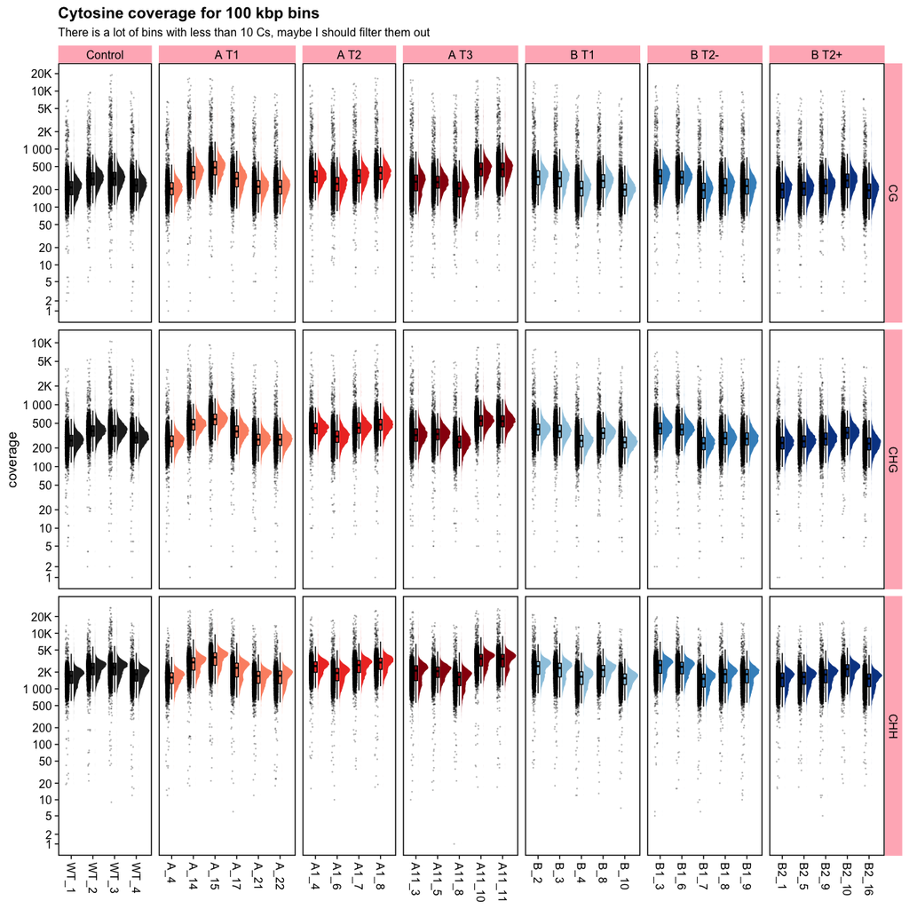

### scatter plot coverage vs %mC

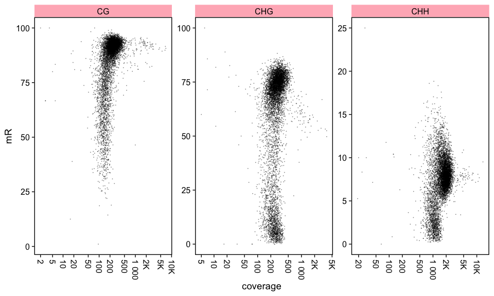

# Boxplots % mC

## Comparing all plants in a line

### %mC

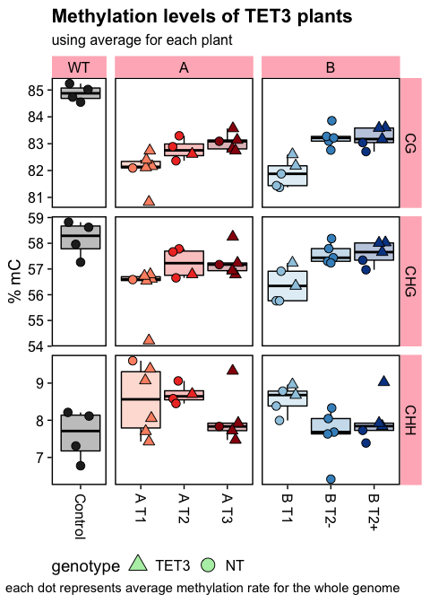

### %mC diff

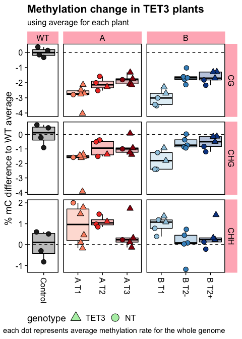

## By sample separately

And now split by context but each boxplot representing the whole set of 100 kb bins

### CG

#### %mC

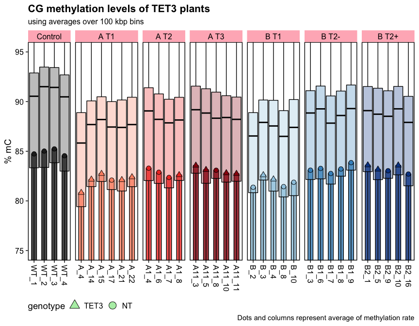

#### %mC difference

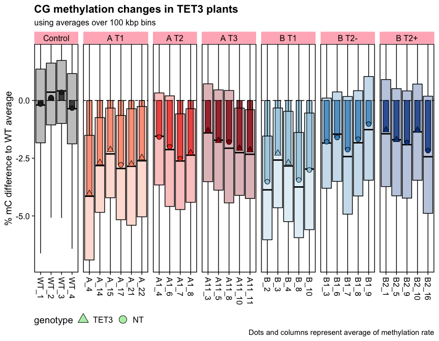

### CHG

#### %mC

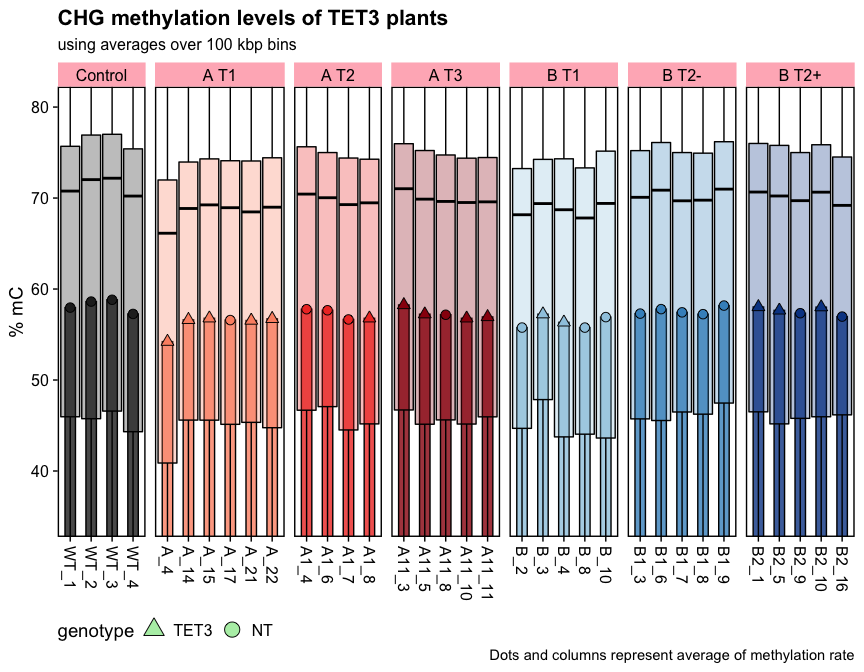

#### %mC difference

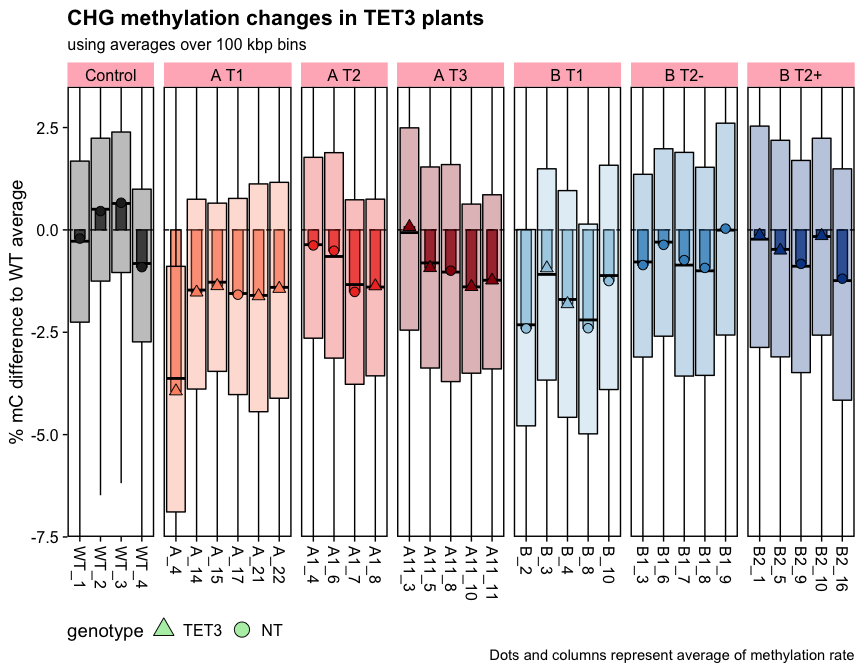

### CHH

#### %mC

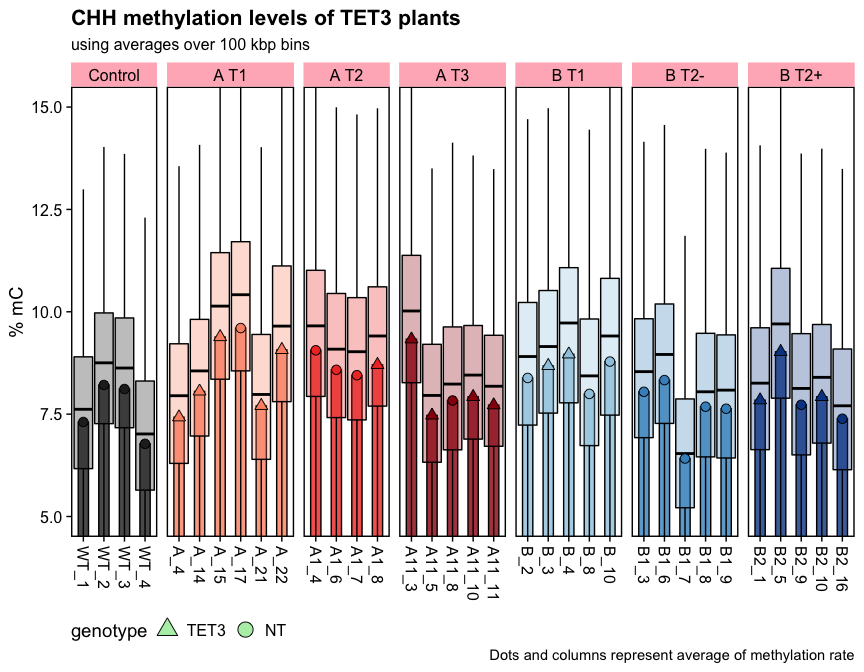

#### %mC difference

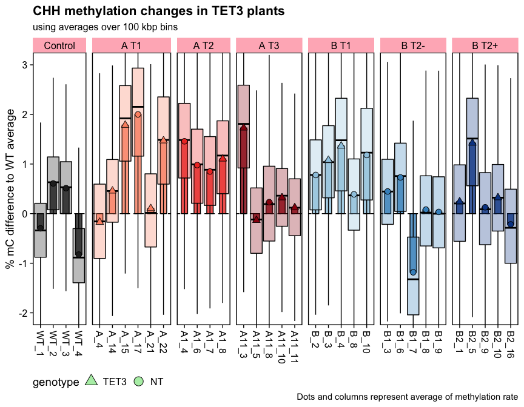

# Split by chromatin state

Using information about location of boundaries between euchromatin and heterochromatin inferred from H3K27mac ChIP-seq data, we can compare the changes in DNA methylation between the two compartments of the genome.

## Comparing all plants in a line

### %mC

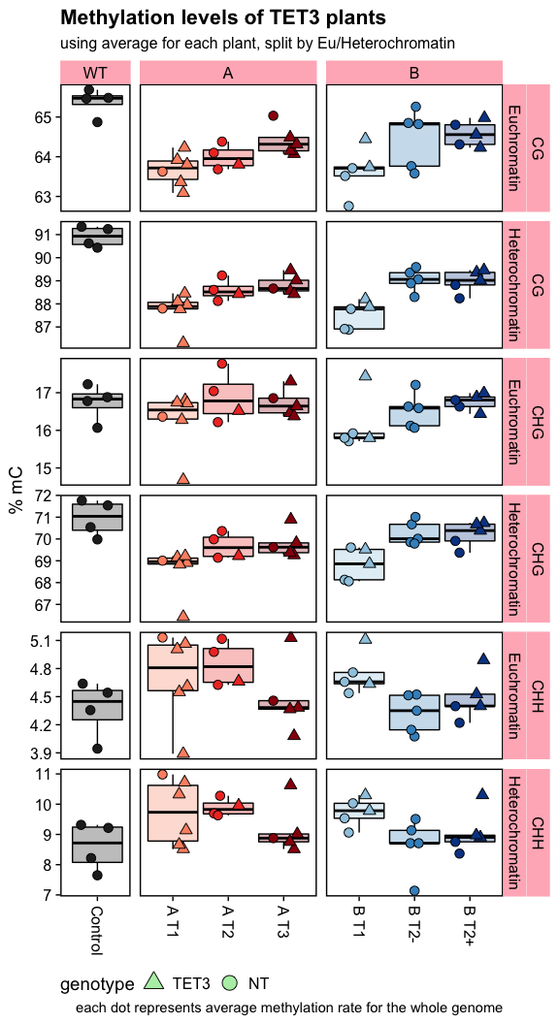

### %mC diff

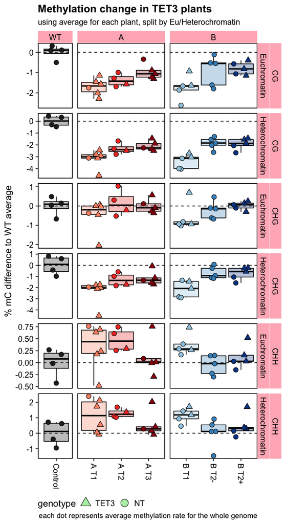

## By sample separately

And now split by context but each boxplot representing the whole set of 100 kb bins

### CG

#### %mC

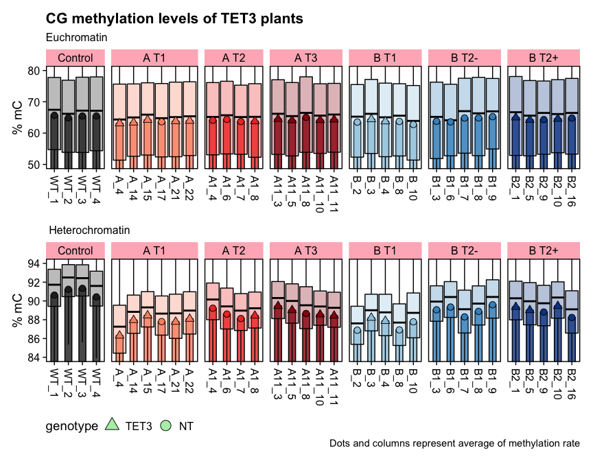

#### %mC difference

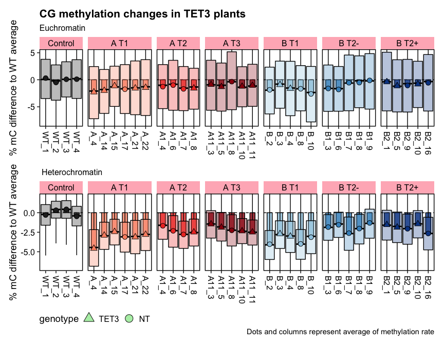

### CHG

#### %mC

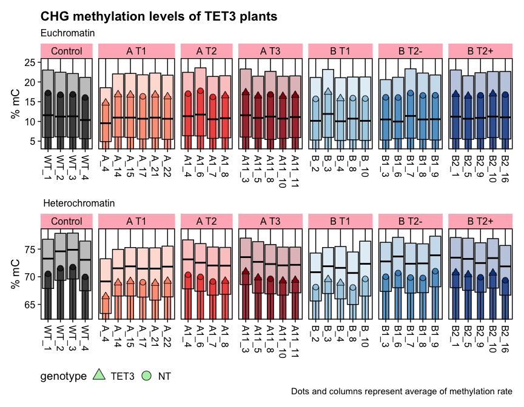

#### %mC difference

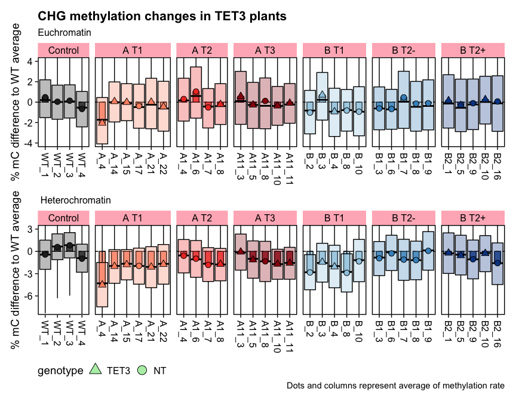

### CHH

#### %mC

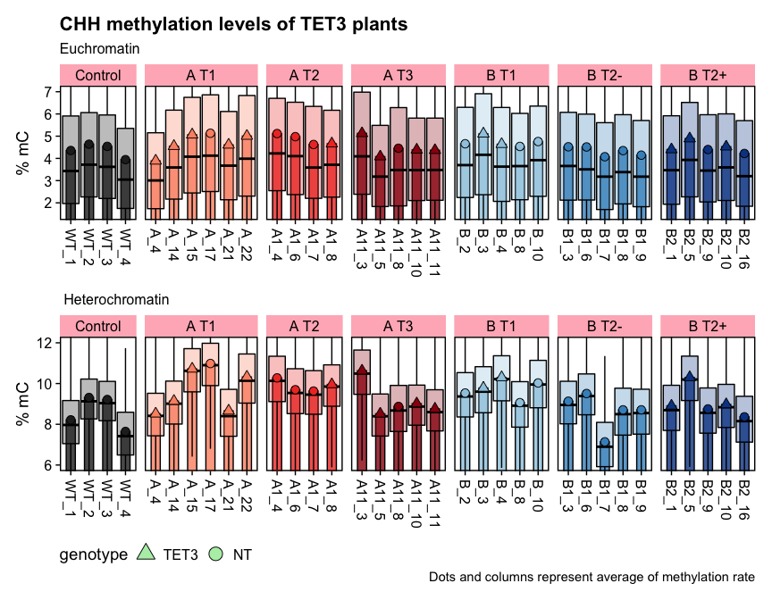

#### %mC difference

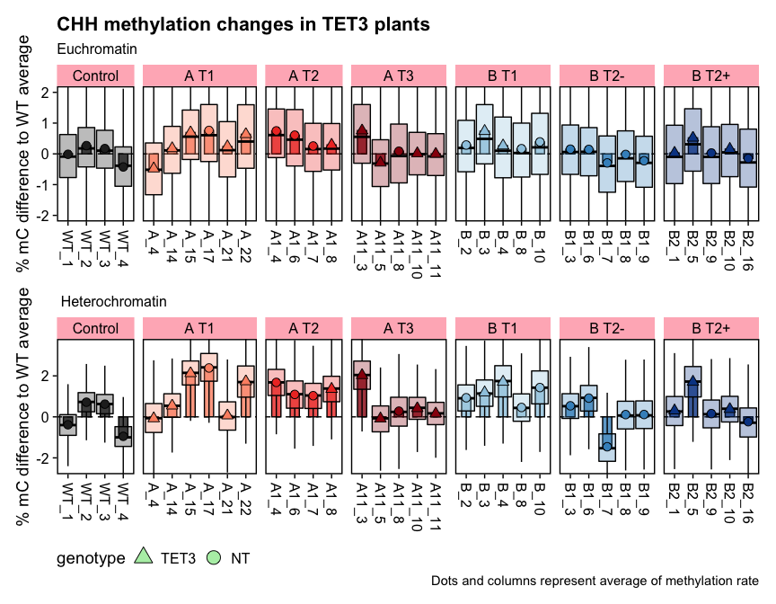

# Other plots of whole genome methylation

## per Chromosome

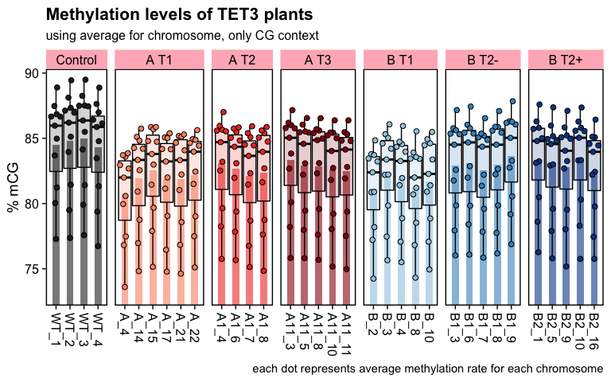

## just average

Average for the whole genome all Cytosines (all contexts mixed)

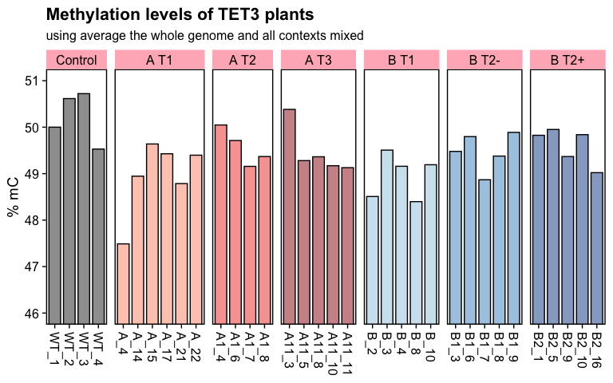

## from bismark reports

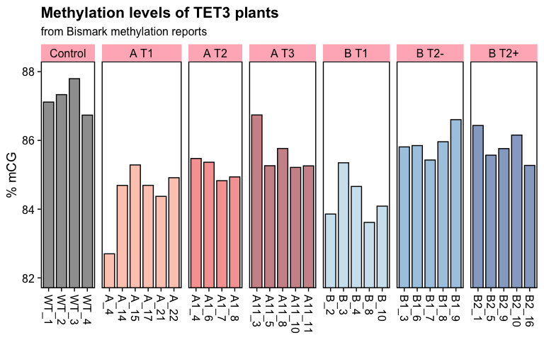

## from old analysis

### new plot

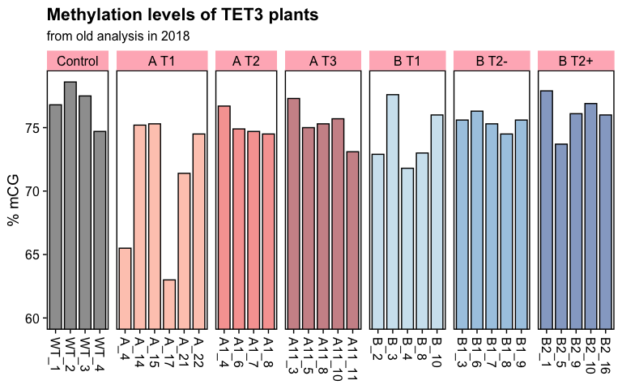

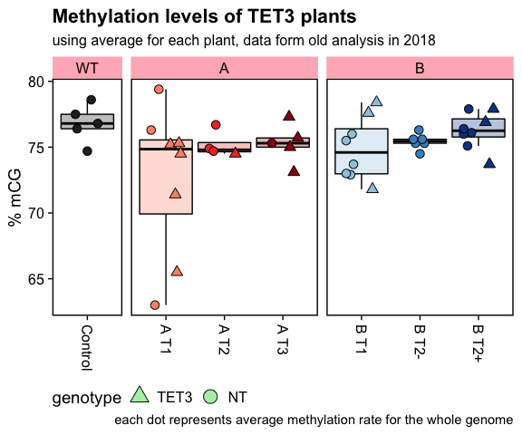

### simple plot

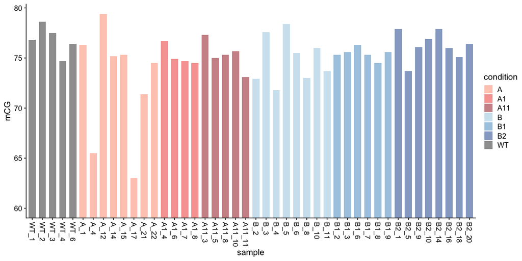